# Praktikum 6 & 7

### Packages

```r
library(ggplot2)
library(tsibble)
library(tseries)
library(MASS)
library(forecast)
library(TSA)
library(TTR)
library(aTSA)
library(graphics)
library(rio)
```

# Input Data

```r
data <- import("https://raw.githubusercontent.com/naylatiara/MPDW/refs/heads/main/pertemuan%201/india_2000_2024_daily_weather%20-%20Sheet1%20(2).csv")

head(data)
```

```
##    KOTA    TANGGAL SUHU_MAX
## 1 Delhi 20/10/2023    29.02
## 2 Delhi 21/10/2023    29.07
## 3 Delhi 22/10/2023    30.03
## 4 Delhi 23/10/2023    29.09
## 5 Delhi 24/10/2023    30.07
## 6 Delhi 25/10/2023    30.09
```

```r
data$TANGGAL <- as.Date(data$TANGGAL, format = "%d/%m/%Y")
data$SUHU_MAX <- as.numeric(data$SUHU_MAX)
```

### Mengubah data agar terbaca sebagai deret waktu

```r
data.ts <- (data$SUHU_MAX)
data.ts
```

```
##   [1] 29.02 29.07 30.03 29.09 30.07 30.09 30.07 30.04 30.00 31.03 31.07 30.09
##  [13] 30.04 30.04 28.05 29.06 29.05 29.04 29.09 29.05 29.02 26.01 25.01 25.01
##  [25] 25.03 25.01 25.06 26.00 26.07 26.01 25.05 25.04 25.03 24.09 24.06 25.00
##  [37] 25.00 25.05 24.02 20.04 24.04 21.02 24.00 24.01 24.03 22.08 23.02 23.05
##  [49] 24.01 23.08 23.04 22.06 21.09 22.08 22.07 22.01 21.08 22.03 22.05 21.06
##  [61] 21.06 20.05 21.05 21.02 22.00 22.07 22.09 22.03 21.05 20.07 19.08 18.04
##  [73] 18.04 16.01 15.00 15.04 17.05 17.01 16.09 17.04 18.04 18.00 15.09 15.03
##  [85] 17.04 17.08 17.07 15.08 17.00 17.08 17.04 16.04 15.08 16.00 16.05 17.02
##  [97] 18.01 17.02 18.03 20.04 20.01 21.02 20.03 19.09 21.00 19.02 20.04 21.01
## [109] 19.07 18.06 18.03 19.00 20.04 19.07 21.04 21.05 21.00 22.06 23.07 24.04
## [121] 24.06 27.05 27.02 27.04 26.01 24.02 23.00 23.01 25.00 24.05 24.03 24.03
## [133] 26.04 26.06 25.02 22.02 21.02 20.05 21.00 23.08 25.01 25.01 26.03 29.03
## [145] 29.02 29.02
```

# Eksplorasi Data

## Plot Data Penuh

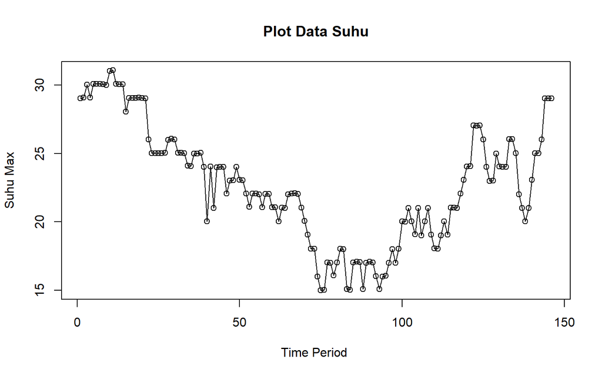

```r
ts.plot(data.ts, xlab="Time Period ", ylab="Suhu Max",
        main = "Plot Data Suhu")
points(data.ts)
```

Berdasarkan plot data deret waktu, terlihat bahwa data memiliki tren yang fluktuatif membentuk pola siklik (turun kemudian naik kembali). Berdasarkan pola data tersebut, pembagian data latih dan data uji ditetapkan dengan proporsi 80%:20%.

## Pembagian Data

Pembagian data latih dan data uji dilakukan dengan perbandingan 80% data latih dan 20% data uji

```r
#hitung jumlah daya
n <- nrow(data)

#tentukan natas 80%
n_train <- floor(0.8 * n)

#bagi data
training <- data[1:n_train, ]
testing <- data[(n_train+1):n, ]

#ubah ke time series
train1.ts <- ts(training$SUHU_MAX)
test1.ts <- ts(testing$SUHU_MAX)
```

## Plot Data Latih

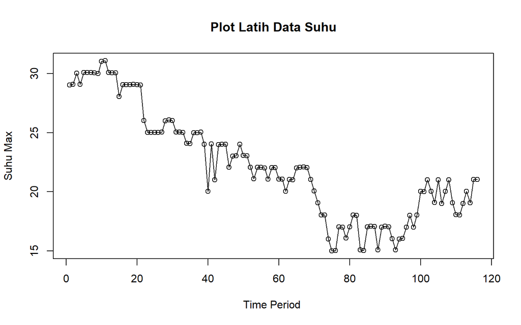

```r
ts.plot(train1.ts, xlab="Time Period ", ylab="Suhu Max",
        main = "Plot Latih Data Suhu")
points(train1.ts)
```

Berdasarkan plot data deret waktu pada data latih, terlihat bahwa data cenderung memiliki tren yang menurun kemudian naik kembali dan tidak bergerak pada nilai tengah tertentu. Hal ini mengindikasikan bahwa data tidak stasioner dalam rataan

### Plot Data Uji

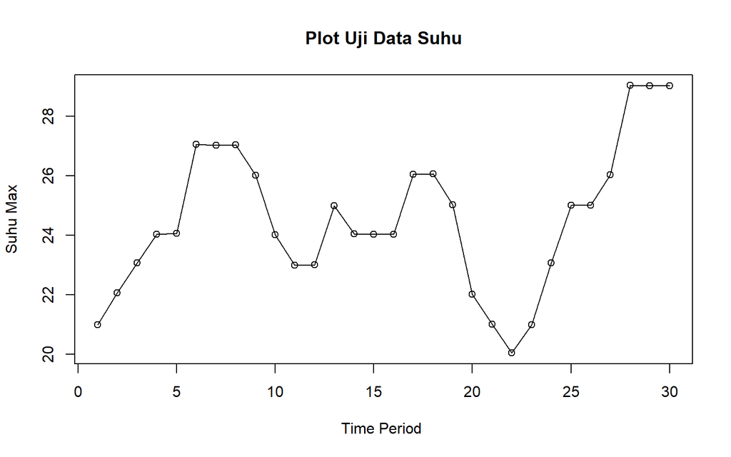

```r
ts.plot(test1.ts, xlab="Time Period ", ylab="Suhu Max",
        main = "Plot Uji Data Suhu")
points(test1.ts)
```

# Uji Stasioneritas Data

## Plot ACF

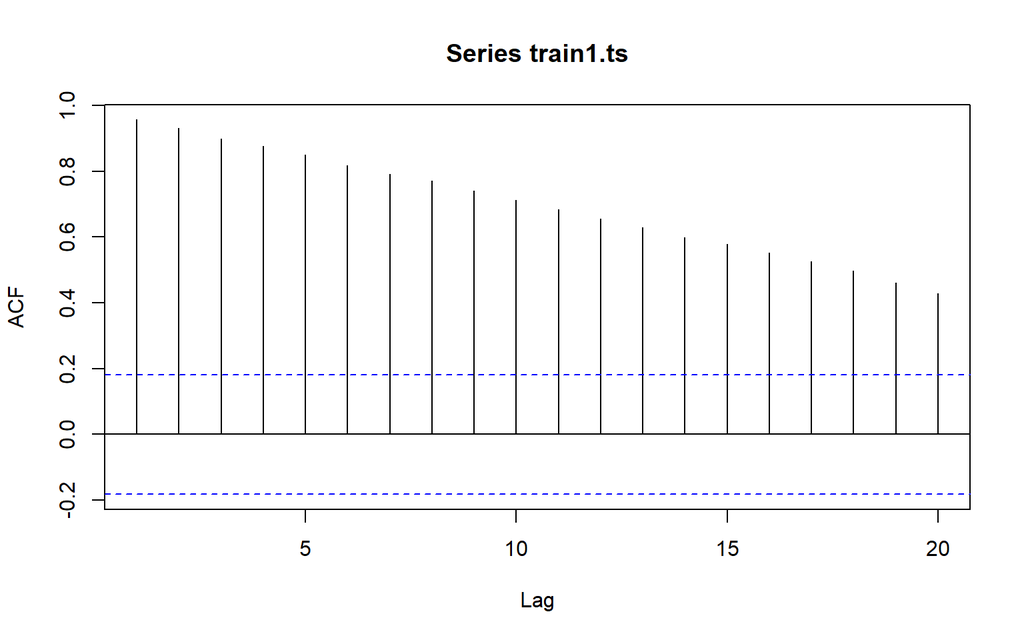

```r
acf(train1.ts)
```

Berdasarkan plot ACF, terlihat bahwa plot ACF data menurun secara perlahan (*tails of slowly*). Hal ini juga menjadi indikasi bahwa data tidak stasioner dalam rataan

## Uji ADF

```r
tseries::adf.test(train1.ts)
```

```
##
##  Augmented Dickey-Fuller Test
##
## data:  train1.ts
## Dickey-Fuller = -0.87988, Lag order = 4, p-value = 0.952
## alternative hypothesis: stationary
```

$H_0$ : Data tidak stasioner dalam rataan

$H_1$ : Data stasioner dalam rataan

Berdasarkan uji ADF tersebut, didapat *p-value* sebesar 0.952 yang lebih besar dari taraf nyata 5% sehingga tak tolak $H_0$ dan menandakan bahwa data tidak stasioner dalam rataan. Hal ini sesuai dengan hasil eksplorasi menggunakan plot time series dan plot ACF, sehingga ketidakstasioneran model kedepannya harus ditangani

## Plot Box-Cox

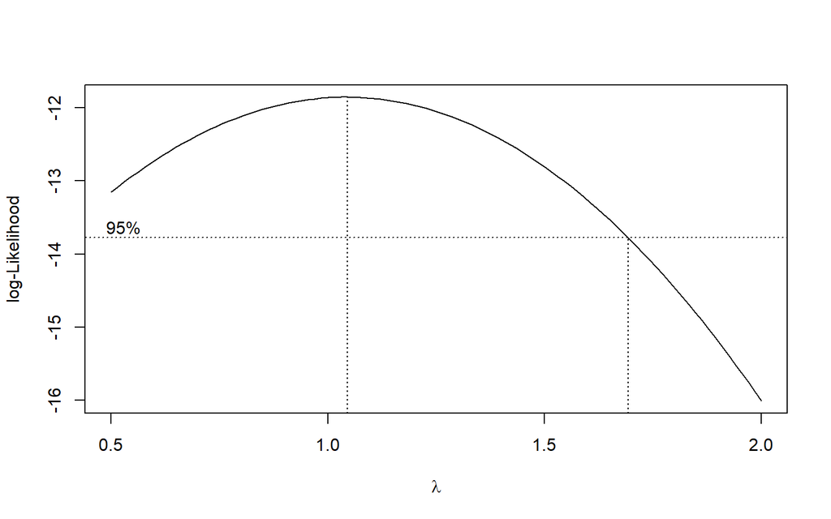

```r
index <- seq(train1.ts)

# Box-Cox
bc <- boxcox(train1.ts ~ index, lambda = seq(0.5, 2, by = 0.1))
```

```r
# Nilai lambda optimum (rounded)
lambda_opt <- bc$x[which.max(bc$y)]
lambda_opt
```

```
## [1] 1.045455
```

```r
# Selang kepercayaan 95% untuk lambda
ci_lambda <- bc$x[bc$y > max(bc$y) - 0.5 * qchisq(0.95, df = 1)]

# Batas bawah dan batas atas
ci_lower <- min(ci_lambda)
ci_upper <- max(ci_lambda)

c(Batas_Bawah = ci_lower, Batas_Atas = ci_upper)
```

```
## Batas_Bawah  Batas_Atas
##    0.500000    1.681818
```

# Penanganan Ketidakstasioneran Data

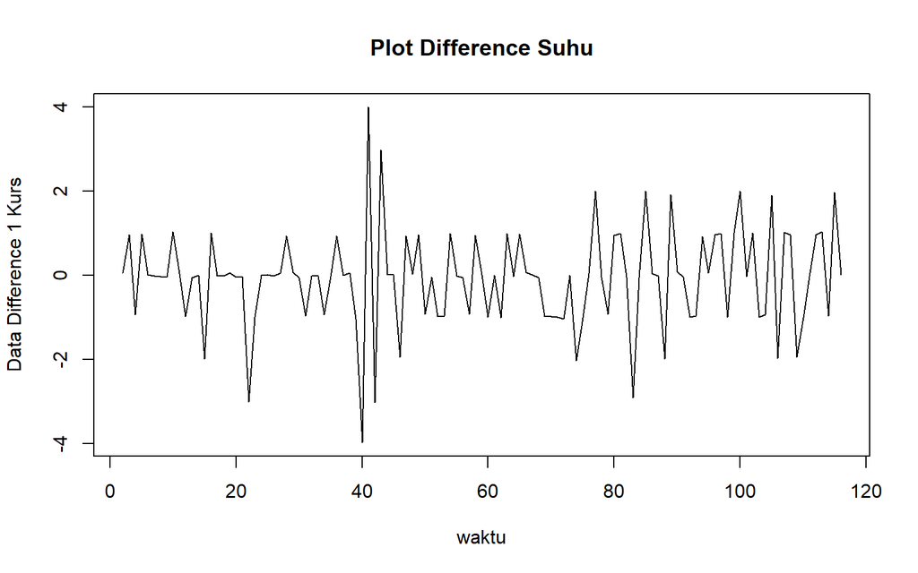

```r
# Dufferencing pertama
train1.diff<-diff(train1.ts,differences = 1)

# Plot hasil differencing
plot.ts(train1.diff, lty=1, xlab="waktu", ylab="Data Difference 1 Kurs", main="Plot Difference Suhu")
```

Berdasarkan plot data deret waktu, terlihat bahwa data sudah stasioner dalam rataan ditandai dengan data bergerak pada nilai tengah tertentu (tidak terdapat trend ataupun musiman pada data)

## Plot ACF

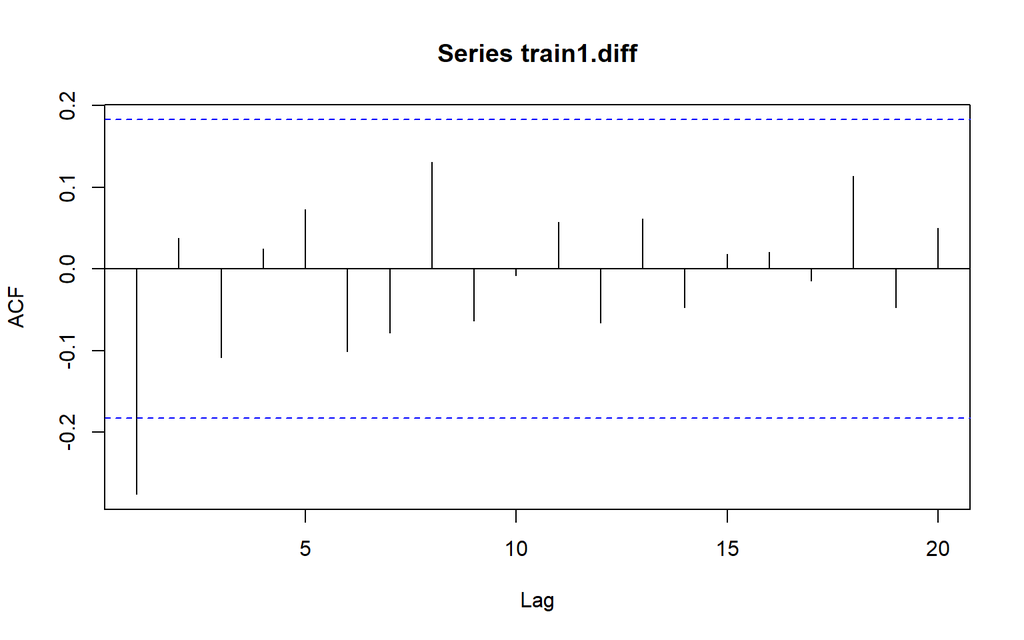

```r
acf(train1.diff)
```

Berdasarkan plot tersebut, terlihat bahwa plot ACF cuts off pada lag ke 1. Hal ini menandakan data sudah stasioner dalam rataan dan ketidakstasioneran data telah berhasil tertangani.

## Uji ADF

```r
tseries::adf.test(train1.diff)
```

```
##
##  Augmented Dickey-Fuller Test
##
## data:  train1.diff
## Dickey-Fuller = -5.0899, Lag order = 4, p-value = 0.01
## alternative hypothesis: stationary
```

$H_0$ : Data tidak stasioner dalam rataan

$H_1$ : Data stasioner dalam rataan

Berdasarkan uji ADF tersebut, didapat *p-value* sebesar 0.01 yang lebih kecil dari taraf nyata 5% sehingga tolak $H_0$ atau data stasioner dalam rataan. Hal ini sesuai dengan hasil eksplorasi menggunakan plot time series dan plot ACF, sehingga dalam hal ini ketidakstasioneran data sudah berhasil ditangani dan dapat dilanjutkan ke pemodelan

## Plot Box-Cox setelah proses differencing

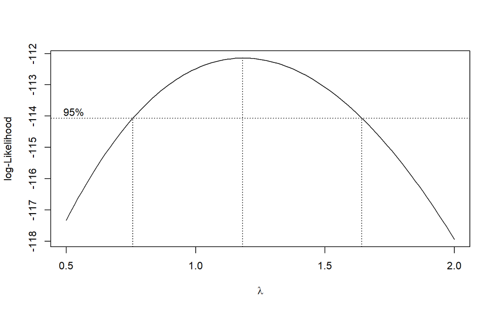

```r
# 1. Sesuaikan panjang index karena differencing menghilangkan 1 observasi awal
index1_diff <- seq(1:length(train1.diff))

# 2. Cek apakah ada nilai negatif/nol. Jika ada, tambahkan konstanta (c)
# agar nilai minimum data menjadi > 0 (misalnya menjadi 1)
min_val <- min(train1.diff)

if (min_val <= 0) {
  c <- abs(min_val) + 1
  train1.diff_shifted <- train1.diff + c
} else {
  train1.diff_shifted <- train1.diff
}

# 3. Plot Box-Cox pada data yang sudah di-shift
bc1_diff <- boxcox(train1.diff_shifted ~ index1_diff, lambda = seq(0.5, 2, by = 0.1))
```

```r
# 4. Nilai lambda optimum (rounded)
lambda_opt1_diff <- bc1_diff$x[which.max(bc1_diff$y)]
print(paste("Lambda optimum setelah diff:", lambda_opt1_diff))
```

```
## [1] "Lambda optimum setelah diff: 1.18181818181818"
```

```r
# 5. Selang kepercayaan 95% untuk lambda
ci_lambda1_diff <- bc1_diff$x[bc1_diff$y > max(bc1_diff$y) - 0.5 * qchisq(0.95, df = 1)]

# Batas bawah dan batas atas
ci_lower1_diff <- min(ci_lambda1_diff)
ci_upper1_diff <- max(ci_lambda1_diff)

c(Batas_Bawah = ci_lower1_diff, Batas_Atas = ci_upper1_diff)
```

```
## Batas_Bawah  Batas_Atas
##   0.7575758   1.6363636
```

# Identifikasi Model

## Plot ACF

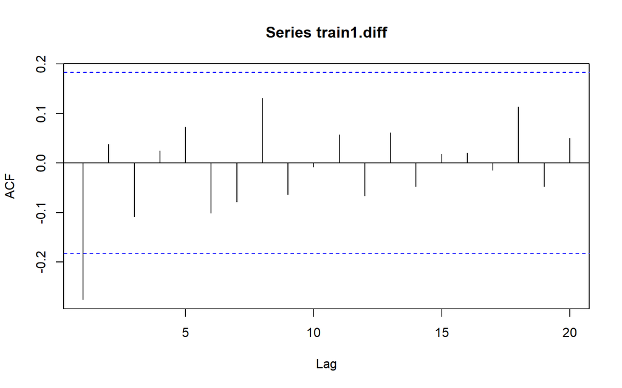

```r
acf(train1.diff)
```

Berdasarkan plot tersebut, terlihat bahwa plot ACF cenderung *cuts off* pada lag ke 1, sehingga jika plot PACF dianggap *tails of*, maka model tentatifnya adalah ARIMA(0,1,1).

## Plot PACF

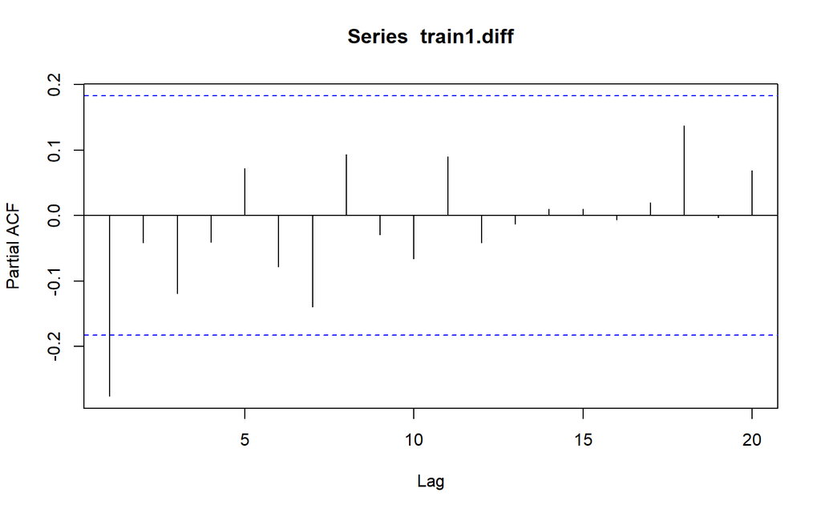

```r
pacf(train1.diff)
```

Berdasarkan plot tersebut, terlihat bahwa plot PACF cenderung *cuts off* pada lag ke 1, sehingga jika plot ACF dianggap *tails of*, maka model tentatifnya adalah ARIMA(1,1,0).

Jika baik plot ACF maupun plot PACF keduanya dianggap tails of, maka model yang terbentuk adalah ARIMA(1,1,1)

## Plot EACF

```r
eacf(train1.diff)
```

```
## AR/MA
##   0 1 2 3 4 5 6 7 8 9 10 11 12 13
## 0 x o o o o o o o o o o  o  o  o
## 1 o o o o o o o o o o o  o  o  o
## 2 x x x o o o o o o o o  o  o  o
## 3 x x x o o o o o o o o  o  o  o
## 4 x o x o o o o o o o o  o  o  o
## 5 x o x o o o o o o o o  o  o  o
## 6 x x x o o x o o o o o  o  o  o
## 7 x o x o o o o o o o o  o  o  o
```

Identifikasi model menggunakan plot EACF dilakukan dengan melihat ujung segitiga pada pola segitiga nol. Dalam hal ini model tentatif yang terbentuk adalah ARIMA(0,1,1), ARIMA(2,1,3), dan ARIMA(3,1,3).

# Pendugaan Parameter Model Tentatif

## Beberapa Model ARIMA

### ARIMA(0,1,1)

```r
model1.da=Arima(train1.diff, order=c(0,0,1),method="ML")
summary(model1.da) #AIC=4752.56
```

```
## Series: train1.diff
## ARIMA(0,0,1) with non-zero mean
##
## Coefficients:
##           ma1     mean
##       -0.3037  -0.0721
## s.e.   0.0940   0.0736
##
## sigma^2 = 1.298:  log likelihood = -177.22
## AIC=360.44   AICc=360.65   BIC=368.67
##
## Training set error measures:
##                       ME     RMSE       MAE MPE MAPE      MASE        ACF1
## Training set 0.001304262 1.129375 0.8634911 NaN  Inf 0.6480447 0.004722955
```

```r
lmtest::coeftest(model1.da) #seluruh parameter signifikan
```

```
##
## z test of coefficients:
##
##            Estimate Std. Error z value Pr(>|z|)
## ma1       -0.303692   0.093952 -3.2324 0.001227 **
## intercept -0.072055   0.073627 -0.9786 0.327755
## ---
## Signif. codes:  0 '***' 0.001 '**' 0.01 '*' 0.05 '.' 0.1 ' ' 1
```

### ARIMA(1,1,0)

```r
model2.da=Arima(train1.diff, order=c(1,0,0),method="ML")
summary(model2.da)
```

```
## Series: train1.diff
## ARIMA(1,0,0) with non-zero mean
##
## Coefficients:
##           ar1     mean
##       -0.2737  -0.0697
## s.e.   0.0892   0.0831
##
## sigma^2 = 1.306:  log likelihood = -177.56
## AIC=361.12   AICc=361.34   BIC=369.36
##
## Training set error measures:
##                        ME     RMSE       MAE MPE MAPE      MASE       ACF1
## Training set 0.0002450597 1.132849 0.8574808 NaN  Inf 0.6435339 -0.0138937
```

```r
lmtest::coeftest(model2.da) #seluruh parameter signifikan
```

```
##
## z test of coefficients:
##
##            Estimate Std. Error z value Pr(>|z|)
## ar1       -0.273704   0.089209 -3.0681 0.002154 **
## intercept -0.069677   0.083094 -0.8385 0.401732
## ---
## Signif. codes:  0 '***' 0.001 '**' 0.01 '*' 0.05 '.' 0.1 ' ' 1
```

### ARIMA(1,1,1)

```r
model3.da=Arima(train1.diff, order=c(1,0,1),method="ML")
summary(model3.da)
```

```
## Series: train1.diff
## ARIMA(1,0,1) with non-zero mean
##
## Coefficients:
##          ar1      ma1     mean
##       0.1611  -0.4567  -0.0739
## s.e.  0.4129   0.3854   0.0688
##
## sigma^2 = 1.308:  log likelihood = -177.15
## AIC=362.3   AICc=362.66   BIC=373.28
##
## Training set error measures:
##                       ME     RMSE       MAE MPE MAPE      MASE         ACF1
## Training set 0.002160466 1.128644 0.8610155 NaN  Inf 0.6461867 -0.008513048
```

```r
lmtest::coeftest(model3.da) #seluruh parameter signifikan
```

```
##
## z test of coefficients:
##
##            Estimate Std. Error z value Pr(>|z|)
## ar1        0.161089   0.412926  0.3901   0.6965
## ma1       -0.456714   0.385375 -1.1851   0.2360
## intercept -0.073878   0.068788 -1.0740   0.2828
```

### ARIMA(1,1,2)

```r
model4.da=Arima(train1.diff, order=c(1,0,2),method="ML")
summary(model4.da)
```

```
## Series: train1.diff
## ARIMA(1,0,2) with non-zero mean
##
## Coefficients:
##          ar1      ma1     ma2     mean
##       0.6880  -0.9849  0.1635  -0.0774
## s.e.  0.4267   0.4393  0.1875   0.0614
##
## sigma^2 = 1.314:  log likelihood = -176.92
## AIC=363.85   AICc=364.4   BIC=377.57
##
## Training set error measures:
##                       ME     RMSE       MAE MPE MAPE      MASE         ACF1
## Training set 0.004392323 1.126376 0.8572365 NaN  Inf 0.6433507 -0.008448474
```

```r
lmtest::coeftest(model4.da) #seluruh parameter signifikan
```

```
##
## z test of coefficients:
##
##            Estimate Std. Error z value Pr(>|z|)
## ar1        0.688026   0.426741  1.6123  0.10690
## ma1       -0.984900   0.439312 -2.2419  0.02497 *
## ma2        0.163526   0.187514  0.8721  0.38317
## intercept -0.077375   0.061439 -1.2594  0.20790
## ---
## Signif. codes:  0 '***' 0.001 '**' 0.01 '*' 0.05 '.' 0.1 ' ' 1
```

### ARIMA(2,1,1)

```r
model5.da=Arima(train1.diff, order=c(2,0,1),method="ML")
summary(model5.da)
```

```
## Series: train1.diff
## ARIMA(2,0,1) with non-zero mean
##
## Coefficients:
##          ar1     ar2      ma1     mean
##       0.4618  0.1303  -0.7677  -0.0774
## s.e.  0.2701  0.1366   0.2485   0.0611
##
## sigma^2 = 1.311:  log likelihood = -176.79
## AIC=363.58   AICc=364.13   BIC=377.3
##
## Training set error measures:
##                       ME     RMSE       MAE MPE MAPE      MASE        ACF1
## Training set 0.004498948 1.125026 0.8573911 NaN  Inf 0.6434666 0.003191971
```

```r
lmtest::coeftest(model5.da) #seluruh parameter signifikan
```

```
##
## z test of coefficients:
##
##            Estimate Std. Error z value Pr(>|z|)
## ar1        0.461783   0.270118  1.7096 0.087347 .
## ar2        0.130346   0.136605  0.9542 0.339993
## ma1       -0.767654   0.248543 -3.0886 0.002011 **
## intercept -0.077435   0.061056 -1.2682 0.204710
## ---
## Signif. codes:  0 '***' 0.001 '**' 0.01 '*' 0.05 '.' 0.1 ' ' 1
```

### ARIMA(2,1,2)

```r
model6.da=Arima(train1.diff, order=c(2,0,2),method="ML")
summary(model6.da)
```

```
## Series: train1.diff
## ARIMA(2,0,2) with non-zero mean
##
## Coefficients:
##          ar1     ar2      ma1      ma2     mean
##       0.0203  0.3001  -0.3217  -0.2880  -0.0769
## s.e.  0.6702  0.2515   0.6723   0.3624   0.0613
##
## sigma^2 = 1.319:  log likelihood = -176.61
## AIC=365.22   AICc=366   BIC=381.69
##
## Training set error measures:
##                       ME     RMSE       MAE MPE MAPE     MASE         ACF1
## Training set 0.004141597 1.123223 0.8529785 NaN  Inf 0.640155 0.0005523232
```

```r
lmtest::coeftest(model6.da) #seluruh parameter signifikan
```

```
##
## z test of coefficients:
##
##            Estimate Std. Error z value Pr(>|z|)
## ar1        0.020303   0.670217  0.0303   0.9758
## ar2        0.300050   0.251521  1.1929   0.2329
## ma1       -0.321695   0.672350 -0.4785   0.6323
## ma2       -0.287976   0.362365 -0.7947   0.4268
## intercept -0.076941   0.061329 -1.2546   0.2096
```

### ARIMA(2,1,3)

```r
model7.da=Arima(train1.diff, order=c(2,0,3),method="ML")
summary(model7.da)
```

```
## Series: train1.diff
## ARIMA(2,0,3) with non-zero mean
##
## Coefficients:
##           ar1      ar2     ma1     ma2      ma3     mean
##       -0.5597  -0.7051  0.2814  0.5881  -0.3642  -0.0741
## s.e.   0.1586   0.1760  0.1635  0.1640   0.0962   0.0684
##
## sigma^2 = 1.269:  log likelihood = -174.08
## AIC=362.16   AICc=363.21   BIC=381.38
##
## Training set error measures:
##                       ME     RMSE       MAE MPE MAPE      MASE         ACF1
## Training set 0.002420315 1.096677 0.8283518 NaN  Inf 0.6216729 -0.001058443
```

```r
lmtest::coeftest(model7.da) #seluruh parameter signifikan
```

```
##
## z test of coefficients:
##
##            Estimate Std. Error z value  Pr(>|z|)
## ar1       -0.559746   0.158600 -3.5293 0.0004167 ***
## ar2       -0.705077   0.176040 -4.0052 6.196e-05 ***
## ma1        0.281450   0.163477  1.7216 0.0851337 .
## ma2        0.588073   0.163958  3.5867 0.0003348 ***
## ma3       -0.364207   0.096222 -3.7851 0.0001537 ***
## intercept -0.074050   0.068396 -1.0827 0.2789511
## ---
## Signif. codes:  0 '***' 0.001 '**' 0.01 '*' 0.05 '.' 0.1 ' ' 1
```

### ARIMA(3,1,1)

```r
model8.da=Arima(train1.diff, order=c(3,0,1),method="ML")
summary(model8.da)
```

```
## Series: train1.diff
## ARIMA(3,0,1) with non-zero mean
##
## Coefficients:
##           ar1      ar2      ar3      ma1     mean
##       -0.0849  -0.0193  -0.1120  -0.2093  -0.0730
## s.e.   0.7672   0.2396   0.1074   0.7737   0.0686
##
## sigma^2 = 1.318:  log likelihood = -176.58
## AIC=365.16   AICc=365.94   BIC=381.63
##
## Training set error measures:
##                       ME     RMSE       MAE MPE MAPE      MASE         ACF1
## Training set 0.001611286 1.122986 0.8494905 NaN  Inf 0.6375373 -0.003050468
```

```r
lmtest::coeftest(model8.da) #seluruh parameter signifikan
```

```
##
## z test of coefficients:
##
##            Estimate Std. Error z value Pr(>|z|)
## ar1       -0.084852   0.767168 -0.1106   0.9119
## ar2       -0.019281   0.239640 -0.0805   0.9359
## ar3       -0.112025   0.107420 -1.0429   0.2970
## ma1       -0.209285   0.773700 -0.2705   0.7868
## intercept -0.073009   0.068599 -1.0643   0.2872
```

### ARIMA(3,1,2)

```r
model9.da=Arima(train1.diff, order=c(3,0,2),method="ML")
summary(model9.da)
```

```
## Series: train1.diff
## ARIMA(3,0,2) with non-zero mean
##
## Coefficients:
##           ar1      ar2      ar3     ma1     ma2     mean
##       -0.5361  -1.0238  -0.3461  0.2671  1.0000  -0.0706
## s.e.   0.0904   0.0366   0.0879  0.0376  0.0354   0.0782
##
## sigma^2 = 1.213:  log likelihood = -173.3
## AIC=360.6   AICc=361.64   BIC=379.81
##
## Training set error measures:
##                         ME     RMSE       MAE MPE MAPE      MASE         ACF1
## Training set -0.0004230701 1.072357 0.7935285 NaN  Inf 0.5955382 -0.006775382
```

```r
lmtest::coeftest(model9.da) #seluruh parameter signifikan
```

```
##
## z test of coefficients:
##
##            Estimate Std. Error  z value  Pr(>|z|)
## ar1       -0.536065   0.090394  -5.9303 3.024e-09 ***
## ar2       -1.023785   0.036603 -27.9702 < 2.2e-16 ***
## ar3       -0.346143   0.087926  -3.9367 8.260e-05 ***
## ma1        0.267062   0.037648   7.0937 1.306e-12 ***
## ma2        0.999999   0.035388  28.2579 < 2.2e-16 ***
## intercept -0.070588   0.078195  -0.9027    0.3667
## ---
## Signif. codes:  0 '***' 0.001 '**' 0.01 '*' 0.05 '.' 0.1 ' ' 1
```

### ARIMA(3,1,3)

```r
model10.da=Arima(train1.diff, order=c(3,0,3),method="ML")
summary(model10.da)
```

```
## Series: train1.diff
## ARIMA(3,0,3) with non-zero mean
##
## Coefficients:
##           ar1      ar2     ar3     ma1     ma2      ma3     mean
##       -0.5447  -0.6865  0.0181  0.2675  0.5714  -0.3803  -0.0743
## s.e.   0.3060   0.3743  0.3178  0.2912  0.3383   0.2951   0.0680
##
## sigma^2 = 1.281:  log likelihood = -174.08
## AIC=364.16   AICc=365.52   BIC=386.12
##
## Training set error measures:
##                       ME     RMSE       MAE MPE MAPE      MASE         ACF1
## Training set 0.002550667 1.096698 0.8278278 NaN  Inf 0.6212796 -0.002168904
```

```r
lmtest::coeftest(model10.da) #seluruh parameter signifikan
```

```
##
## z test of coefficients:
##
##            Estimate Std. Error z value Pr(>|z|)
## ar1       -0.544704   0.306049 -1.7798  0.07511 .
## ar2       -0.686506   0.374299 -1.8341  0.06664 .
## ar3        0.018104   0.317834  0.0570  0.95458
## ma1        0.267474   0.291224  0.9184  0.35838
## ma2        0.571425   0.338312  1.6890  0.09121 .
## ma3       -0.380273   0.295059 -1.2888  0.19747
## intercept -0.074279   0.067962 -1.0929  0.27442
## ---
## Signif. codes:  0 '***' 0.001 '**' 0.01 '*' 0.05 '.' 0.1 ' ' 1
```

## Ringkasan AIC

```r
model_tentatif1 <- data.frame(
  Model = c("ARIMA(0,1,1)","ARIMA(1,1,0)","ARIMA(1,1,1)", "ARIMA(1,1,2)", "ARIMA(2,1,1)", "ARIMA(2,1,2)", "ARIMA(2,1,3)", "ARIMA(3,1,1)", "ARIMA(3,1,2)", "ARIMA(3,1,3)"),
  AIC   = c(AIC(model1.da),AIC(model2.da), AIC(model3.da), AIC(model4.da), AIC(model5.da), AIC(model6.da), AIC(model7.da), AIC(model8.da), AIC(model9.da), AIC(model10.da)),
  BIC   = c(BIC(model1.da),BIC(model2.da), BIC(model3.da), BIC(model4.da), BIC(model5.da), BIC(model6.da), BIC(model7.da), BIC(model8.da), BIC(model9.da), BIC(model10.da))
)

model_tentatif1
```

```
##           Model      AIC      BIC
## 1  ARIMA(0,1,1) 360.4355 368.6703
## 2  ARIMA(1,1,0) 361.1229 369.3577
## 3  ARIMA(1,1,1) 362.2972 373.2769
## 4  ARIMA(1,1,2) 363.8495 377.5742
## 5  ARIMA(2,1,1) 363.5777 377.3024
## 6  ARIMA(2,1,2) 365.2181 381.6877
## 7  ARIMA(2,1,3) 362.1608 381.3753
## 8  ARIMA(3,1,1) 365.1626 381.6322
## 9  ARIMA(3,1,2) 360.5967 379.8113
## 10 ARIMA(3,1,3) 364.1575 386.1169
```

# Analisis Sisaan

Model terbaik hasil identifikasi kemudian dicek asumsi sisaannya. Sisaan model ARIMA harus memenuhi asumsi normalitas, kebebasan sisaan, dan kehomogenan ragam. Diagnostik model dilakukan secara eksplorasi dan uji formal.

## Eksplorasi Sisaan

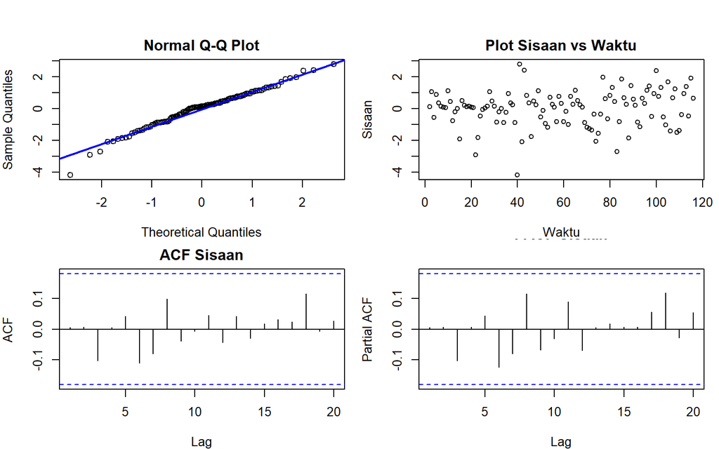

```r
sisaan1.da <- model1.da$residuals

par(mfrow = c(2,2),
    mar = c(4,4,2,1),
    oma = c(0,0,2,0))

# Q-Q Plot
qqnorm(sisaan1.da, main = "Normal Q-Q Plot")
qqline(sisaan1.da, col = "blue", lwd = 2)

# Plot Sisaan vs Waktu
plot(sisaan1.da, type = "p",
     main = "Plot Sisaan vs Waktu",
     xlab = "Waktu", ylab = "Sisaan")

# ACF
acf(sisaan1.da, main = "ACF Sisaan")

# PACF
pacf(sisaan1.da, main = "PACF Sisaan")
```

Berdasarkan Normal Q-Q Plot, titik-titik sisaan terlihat menyebar dan mengikuti garis lurus diagonal secara cukup baik, meskipun terdapat sedikit deviasi di ujung-ujung bawah. Hal ini mengindikasikan bahwa sisaan model ARIMA(0,1,1) berdistribusi normal atau mendekati normal

Berdasarkan Plot ACF Sisaan, seluruh batang pada berbagai lag berada di dalam batas selang kepercayaan. Tidak ada satupun lag yang keluar atau signifikan. Hal ini menunjukkan bahwa tidak terdapat autokorelasi yang signifikan pada sisaan, sehingga sisaan memenuhi asumsi white noise.

Berdasarkan Plot PACF Sisaan, seluruh batang pada setiap lag juga berada di dalam batas selang kepercayaan. Hal ini semakin memperkuat asumsi bahwa sisaan saling bebas secara parsial.

## Uji Formal

### 1) Sisaan Menyebar Normal

```r
#1) Sisaan Menyebar Normal
ks.test(sisaan1.da,"pnorm")  #gagal tolak H0 > sisaan menyebar normal
```

```
##
##  Asymptotic one-sample Kolmogorov-Smirnov test
##
## data:  sisaan1.da
## D = 0.10131, p-value = 0.1886
## alternative hypothesis: two-sided
```

$H_0$ : Sisaan menyebar normal

$H_1$ : Sisaan tidak menyebar normal

Berdasarkan uji KS tersebut, didapat *p-value* sebesar 0.1886 yang lebih dari taraf nyata 5% sehingga gagal tolak $H_0$ dan menandakan bahwa sisaan menyebar normal. Hal ini sesuai dengan hasil eksplorasi menggunakan plot kuantil-kuantil normal.

### 2) Sisaan saling bebas/tidak ada autokorelasi

```r
Box.test(sisaan1.da, type = "Ljung") #gagal tolak H0 > sisaan saling bebas
```

```
##
##  Box-Ljung test
##
## data:  sisaan1.da
## X-squared = 0.0026327, df = 1, p-value = 0.9591
```

Selanjutnya akan dilakukan uji formal untuk kebebasan sisaan menggunakan uji Ljung-Box. Hipotesis yang digunakan adalah sebagai berikut.

$H_0$ : Sisaan saling bebas

$H_1$ : Sisaan tidak tidak saling bebas

### 3) Sisaan homogen

```r
Box.test((sisaan1.da)^2, type = "Ljung")  #gagal tolak H0 > sisaan homogen
```

```
##
##  Box-Ljung test
##
## data:  (sisaan1.da)^2
## X-squared = 7.0456, df = 1, p-value = 0.007946
```

Hipotesis yang digunakan untuk uji kehomogenan ragam adalah sebagai berikut.

$H_0$ : Ragam sisaan homogen

$H_1$ : Ragam sisaan tidak homogen

### 4) Nilai tengah sisaan sama dengan nol

```r
t.test(sisaan1.da, mu = 0, conf.level = 0.95)  #gagal tolak h0 > nilai tengah sisaan sama dengan 0
```

```
##
##  One Sample t-test
##
## data:  sisaan1.da
## t = 0.01233, df = 114, p-value = 0.9902
## alternative hypothesis: true mean is not equal to 0
## 95 percent confidence interval:
##  -0.2082364  0.2108450
## sample estimates:
##   mean of x
## 0.001304262
```

Terakhir, dengan uji-t, akan dicek apakah nilai tengah sisaan sama dengan nol. Hipotesis yang diujikan sebagai berikut.

$H_0$ : nilai tengah sisaan sama dengan 0

$H_1$ : nilai tengah sisaan tidak sama dengan 0